```python
%%javascript
IPython.OutputArea.prototype._should_scroll = function(lines) {
    return false;
}
```

```python
# to load images for this tutorial
from IPython.display import Image
import os
path = os.getcwd()
```

# Post Overview.

1. An Introduction to One Sample T-Test.
2. Discuss the Assuptions of a One Sample T-Test.
3. One Sample T-Test Hypotheses Statements and Formulas.
4. Demonstrate how perform a One Sample T-Test using SPSS.
5. Infographic Overview on One Sample T-Test.

# An Introduction to One Sample T-Test.

#### Introduction

- One Sample T-Test is also called a *Single-Parameter T-Test* or a *Single-Sample T-Test*.
- This test is used to determine whether a sample comes from a population with a specific mean.
- The population mean is not always known, but is theorized.
- Common use of One Sample T Test:
  - Statistical difference between a sample mean and a known or hypothesized population mean.
  - Statistical difference between a sample mean and a specific value.
- In other words, a one-sample t-test is also often used as part of a sampling strategy or to make a comparison to a criterion measure.
- **Sampling Accuracy/Adequacy Example:**
  - An education analyst wants to compare the mean math scores of a high school to the national average.
  - **Generalized Research Question:** Is there a difference in variable of interest between the sample and population?
  - A one-sample t-test would help the analyst determine if this high school score is representative of the population (national average).
- **Comparison to a Criterion Measure Example:**
  - Human Resources wants to investigate whether Research Associates in the School of Medicine are working more than 50 hours per week.
  - **Generalized Research Question:** Is there a difference in variable of interest to some specific criteria (number)?
  - A one-sample t-test would help Human Resources determine if the Research Associates are working more than the 50 hour per week criteria.

# Discuss the Assuptions of a One Sample T-Test.

**What are assumptions?**

- Assumptions are characteristics about a given data.
- A few examples of statistical assumptions include:
  - **Data types:** the data has a specific attribute (integer, continuous, categorical, string, boolean).
  - **Normality:** the data has a normal distribution.
  - **Homogenity of variance:** the data from multiple groups have the same variance.
  - **Linearity:** the data has a linear relationship.
  - **Independence:** the data has a specific attribute.

**Why test for assumptions?**

- Statistical tests are developed taking characteristics of the data into consideration
- Failure to test for these assumptions can result in inaccurate conclusions.
- Part of the process of conducting a statistical test is to make sure the data you want to analyze passes the assumptions needed for this test.
- There are **four assumptions** in a One-sample t-test that must be met to give you valid results.
- It is common for data to violate some of these assumptions, and the aim of this section is to discuss how to proceed in those cases.

**The Four Assumptions**

1. One of the dependent variable is continuous data.
2. The data are Independent and are not correlated/related.
3. No significant outliers.
4. Dependent variable should be approximately normally distributed.

# One Sample T-Test Hypotheses Statements and Formulas.

- The null hypothesis \({H_{0}} \):  
  \[H_{0}: \mu = \mu_{o}\]
- Where \({\mu} \) = sample mean
- and \({\mu_{0}} \) = known or hypothesized population mean.
- The null hypothesis states that the sample mean is equal to the known or hypothesized population mean.
- The alternative hypothesis \({H_{a}} \):  
  \[H_{0}: \mu \neq \mu_{o}\]
- Where \({\mu} \) = sample mean
- and \({\mu_{0}} \) = known or hypothesized population mean.
- The alternative hypothesis states that the sample mean is not equal to the known or hypothesized population mean.

# T-Test Formula

1. - \[t = \frac{\bar X - \mu}{\frac {s}{\sqrt{n}}} \]
   - Where \({\bar X} \) = sample mean
   - and \({\mu} \) = population mean
   - and \({s} \) = sample deviation

# Demonstrate how perform a One Sample T-Test using SPSS.

#### Steps

1. State Question and Hypothesis.
2. Set up your data.
3. Confirm that data does not violate assuption 1 (dependent variable is continuous) and 2 (independence of variables).
4. Test for significant outliers.
5. Determine if data is normally distributes by using test for normality.
6. Carry out One-Sample T-Test and Interpret Results.
7. Infographic Overview on One-Sample T-Test.

### State Question and Hypothesis

- An animal behavioral scientist wants to study hostility in dogs housed in shelters located in low income neighborhoods.
- The scientist used a method to score hostility, which is as follows:
  - Fearful behavior < `4.0`.
  - Normal behavior = `4.0`.
  - Hostile behavior > `4.0`.
- The animal behavioral scientist was able to recruit 40 participants in this study, and behavioral scores were recorded.
- **Question:** Is the sample representative of the normal population (i.e., is the mean score statistically significantly different from 4.0?)
- The null hypothesis states that the sample mean is equal to the known or hypothesized population mean.
- The null hypothesis \({H_{0}} \):  
  \[H_{0}: \mu = 4.0\]
- Where \({\mu} \) = sample mean
- and \({\mu_{0}} \) = known or hypothesized population mean, `4.0`.
- The alternative hypothesis states that the sample mean is not equal to the known or hypothesized population mean.
- The alternative hypothesis \({H_{a}} \):  
  \[H_{0}: \mu \neq 4.0\]
- Where \({\mu} \) = sample mean
- and \({\mu_{0}} \) = known or hypothesized population mean, `4.0`.

**State level of significance α**

- is a value in a given hypothesis test for which a P-value less than or equal to is is considered statistically significant.
- α = 0.05

### Step 2: Set up data

**SPSS Variable View**

- Set up variable in variable view.
- Either import or manually input data.
- The data is continuous, so the measure is set to `Scale`

[figure not shown]

```python
img = os.path.join(path, 'static/images/spss1.png')
Image(filename=img,  width = 800)
```

**SPSS Data View**

- If the study does not meet these two assumptions, then a one-sample t-test is the incorrect statistical test.
- Assumption 1: Continous data. The hostility score takes any value between 0 - 10, and as a result, it is a continuous data, and met the first assumption.  
  Data Passes Assumption 1
- Assumption 2: Independence of observations. Each score was obtained from a single dog, a dog was analyzed only once. These conditions make each observation independent of each other.  
  Data Passes Assumption 2

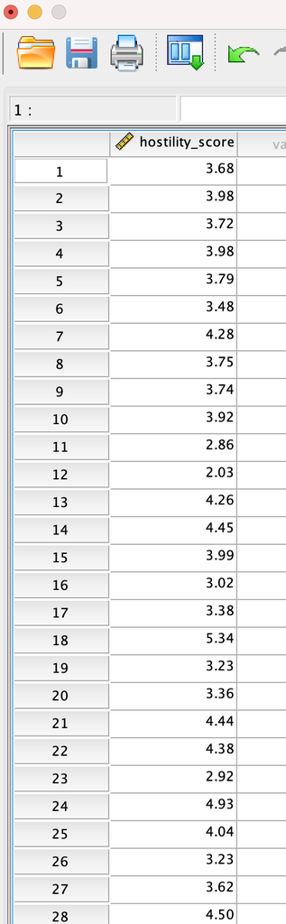

```python
img = os.path.join(path, 'static/images/spss2.png')
Image(filename=img,  width = 150)
```

### Step 4: Test for significant outliers

**Procedure**

1. `Analyze > Explore`
2. `Explore Dialogue Box` move dependent variable into `Dependent List Box`.
3. Click `Plots` button to open `Explore: Plots Dialogue Box`.
4. `Explore: Plots Dialogue Box` Check `Normality plots with tests`.
5. `Explore: Plots Dialogue Box` In `Descriptive` area, uncheck `Stem-and-leaf`.
6. Click `Continue` botton.
7. Retruned to `Explore: Plots Dialogue Box` and in `Display` box, click `Plots` radial dial button.
8. Click `OK`

**Inspect BoxPlot**

- Any data points that are more than 1.5 box-lengths from the edge of their box are classified by SPSS Statistics as outliers.
- SPSS labels extreme data points with circular dots and labeled with a case number (corresponds to the row in the `Data View` window.
- Any data points that are more than 3 box-lengths from the edge of their box are classified as extreme points.
- There are more complicated methods to detect outliers, but this method is the most popular.
- Conclusion: There were no outliers in the data, as assessed by inspection of a boxplot for values greater than 1.5 box-lengths from the edge of the box.

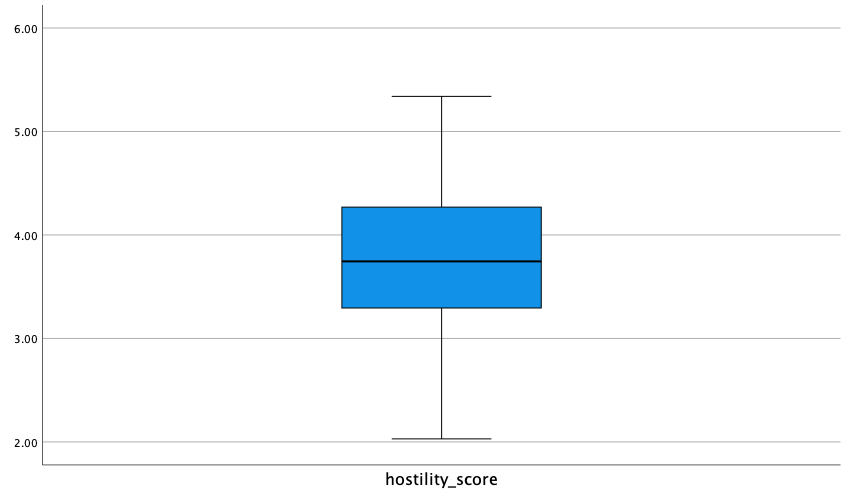

```python
img = os.path.join(path, 'static/images/spss3.png')
Image(filename=img,  width = 500)
```

### Step 5: Determine if data is normally distributes by using tests for normality.

- There are various methods that can be used to determine if the data is normally distributed.
- In this study employs the **Shapiro-Wilk test for normality** and a **Normal Q-Q Plots**.
- Shapiro-Wilk test is recommended if you have a sample size of less than 50 participants.

**Shapiro-Wilk test**

1. `Analyze > Descriptive Statistics > Explore`
2. `Explore Dialogue Box` Move dependent variable to `Dependent list`
3. `Explore Dialogue Box` Click `Plots`
4. `Explore Plots Dialogue Box` click `Normality plots with tests`
5. `Explore Plots Dialogue Box` uncheck `Stem-and-leaf` check `Histogram`
6. `Explore Plots Dialogue Box` click `None` in `Boxplots area`
7. Click `Continue` button
8. `Explore Dialogue Box` click `OK` button

**Interpret result**

- Look at the last column in the `Shapiro-Wilk` section of **Test of Normality** Output table.
- - If \(\textbf{p-value < 0.05} \) then the results are statistically significant. Data is not normally distributed.
  - If \(\textbf{p-value > 0.05} \) then the results are not statistically significant. Data is normally distributed.
  - The p-value = 0.847; The sig value is greater than the α = 0.05, therefore, the behavioral scores are normally distributed.
- The behavioral scores were normally distributed, as assessed by Shapiro-Wilk's test (p > .05).
- If the data was not normally distributed, then there are two options:
  1. Transform data and retest for normality.
  2. Use a nonparametric test

**Testing for normality using Normal Q-Q plots**

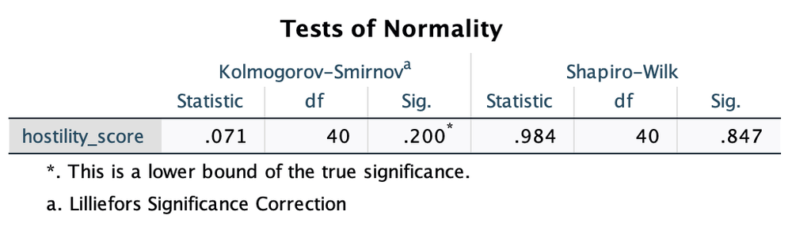

```python
img = os.path.join(path, 'static/images/spss5.png')
Image(filename=img,  width = 500)
```

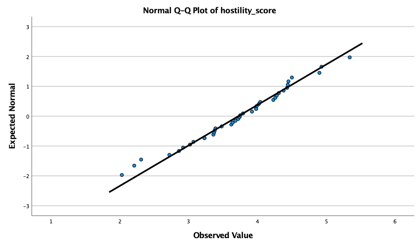

```python
img = os.path.join(path, 'static/images/spss4.png')
Image(filename=img,  width = 500)
```

### Step 6: Carry out One-Sample T-Test and Interpret Results.

**Procedure**

1. `Analyze > Compare Means > One-Sample T Test`
2. `One-Sample T Test dialogue box`
3. Transfer the dependent variable into the `Test Variable(s)` box
4. In `Test Value` area, type in test value `4.0` in our example.
5. Click on `Options` button and in `One-Sample T Test: Options dialogue box` keep conditions as default, click on `Continue` botton.
6. Click on `Continue` botton and then Click on `OK` button to generate output.

**Interpretations of results: Descriptive Statistics**

**Interpretations of results: One-Sample Test**

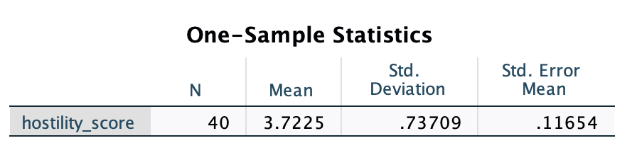

```python
img = os.path.join(path, 'static/images/spss6.png')
Image(filename=img,  width = 500)
```

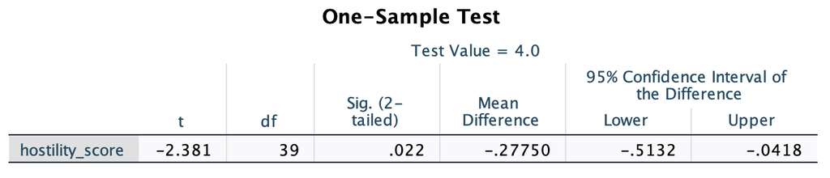

```python
img = os.path.join(path, 'static/images/spss7.png')
Image(filename=img,  width = 500)
```

# Infographic Overview of One-Sample T-Test.

[figure not shown]

```python
img = os.path.join(path, 'static/images/spss9.png')
Image(filename=img, width=800)
```